# GDP Growth and Unemployment in the Netherlands and Western Europe (2015–2025)

## 3.6 Event Analysis

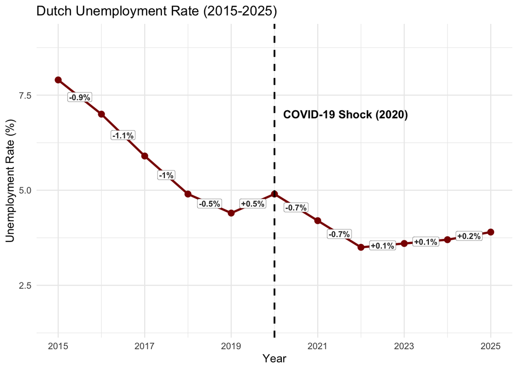

The labelled changes show unemployment fell steadily before 2020 (around -1 ppt per year), then rose by only +0.5 ppt in the COVID-19 year. This increase is remarkably small given the sharp GDP contraction that year, most likely because the Dutch emergency wage-subsidy scheme (NOW) kept workers formally employed, temporarily weakening the usual Okun’s Law relationship.

# Part 4 - Discussion

## 4.1 Discuss your findings

These results should be read with caution, and several limitations bound them. First, we document associations, not causal effects: GDP and unemployment are jointly shaped by labour-market policy, demographic change, and monetary conditions, and 2020 shows clearly how a raw correlation can mislead when a wage-subsidy scheme breaks the usual link. Second, the series is short (eleven annual observations), which makes any estimated Okun coefficient fragile and rules out distinguishing a genuine structural break from noise. Third, the time-series analysis covers only the Netherlands, so findings need not generalise to countries with different labour-market institutions. Fourth, the spatial comparison rests on a single year and eight countries, limiting how far the cross-section can be read as structural. Finally, mixing a survey-based unemployment series with an administrative GDP series introduces definitional mismatch that we cannot fully net out.

# Part 5 - Reproducibility

## 5.1 Github repository link

https://github.com/jackievahtera/PFE_Group_Project

## 5.2 How to reproduce this report

The repository contains this report (`betaversion.Rmd`), a `data/` folder with the three Eurostat CSV extracts (`raw_gdp.csv`, `raw_unemployment_sex.csv`, `raw_unemployment_youth.csv`), the bibliography (`references.bib`), and a `README.md` with a project overview.

To reproduce the report: (1) clone the repository, (2) open `ProgrForEconom.Rproj` in RStudio, (3) make sure the three CSVs are in the `data/` folder, (4) install the required packages (`tidyverse`, `maps`), and (5) knit `betaversion.Rmd` to PDF. Knitting re-reads the raw data and regenerates every figure and statistic in the document. All file paths in the `.Rmd` are relative to the project root, so the project runs on any machine without changes.

## 5.3 Reference list

Eurostat. (2025). Real GDP growth rate; Total unemployment rate; Youth unemployment rate [Data sets, tables tec00115, tesem120, tipslm80]. https://ec.europa.eu/eurostat

Eurofound. (2017). *Long-term unemployment*. Publications Office of the European Union.

Okun, A. M. (1962). Potential GNP: Its measurement and significance. *Proceedings of the Business and Economic Statistics Section*, 98–104.